# Predicting Grades

### Background and Question

This data was collected from Brother Saunders’ MAT 325 class from two semesters ago. Data was collected in regards to the student’s final grade, their final exam score, the days that they missed and a categorical column on how many days were missed. The data is shows in the following link.

##### The DataSet

For this analysis we are hoping to see the probability that a student will earn an A in Math 325 based on their Final Exam score and whether they missed Few, Many, or No classes during the semester.

### Data Analysis

To start this analyis, we will run the logistic regression to see what the data can answer in regards to our question.

```r
Grades1.glm <- glm( (CourseGrade == "A") ~ FinalExamScore + Missed, data=Grades, family=binomial)
pander(summary(Grades1.glm))
```

|  | Estimate | Std. Error | z value | Pr(>\|z\|) |
| --- | --- | --- | --- | --- |
| **FinalExamScore** | 20.96 | 10.68 | 1.963 | 0.04966 |
| **MissedMany** | -2.7 | 1.674 | -1.613 | 0.1068 |
| **MissedNone** | 3.819 | 2.568 | 1.487 | 0.137 |
| **(Intercept)** | -14.62 | 7.729 | -1.892 | 0.05849 |

(Dispersion parameter for binomial family taken to be 1 )

| Null deviance: | 33.65 on 24 degrees of freedom |
| --- | --- |
| Residual deviance: | 15.70 on 21 degrees of freedom |

After running the logistic regression, we are able to see some interesting statistics. With our alpha being 0.05, we see that only onve variable may have sufficient evidence.

Now that we have run a test on the data, we must see if the test was actually a good fit for this analysis. We do this by running the hoslem.test command.

```r
pander(hoslem.test(Grades1.glm$y, Grades1.glm$fitted.values))
```

Hosmer and Lemeshow goodness of fit (GOF) test: `Grades1.glm$y, Grades1.glm$fitted.values`

| Test statistic | df | P value |
| --- | --- | --- |
| 6.444 | 8 | 0.5976 |

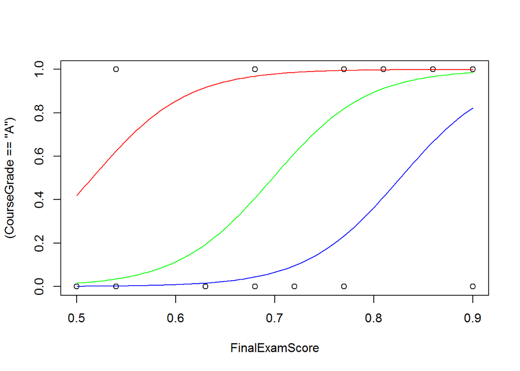

```r
plot( (CourseGrade == "A") ~ FinalExamScore, data=Grades)
curve( exp(-14.624 + 20.958*x)/(1 + exp(-14.624 + 20.958*x)), col="green", add=TRUE)
curve( exp(-14.624 + 20.958*x + -2.700)/(1 + exp(-14.624 + 20.958*x + -2.700)), col="blue", add=TRUE)
curve( exp(-14.624 + 20.958*x + 3.819)/(1 + exp(-14.624 + 20.958*x + 3.819)), col="red", add=TRUE)
```

### Interpretation

We interpret the `FinalExamScore` variable as the effect that the final exam score will have on the odds of getting an “A” in the class, $e^{20.96} = 1.2671042\times 10^{9}$. This means there is a very high increase in the odds of a student receiving an “A” in Brother Saunder’s 325 class.

The final conclusion is that there is sufficient evidence, p-value < 0.05, to conclude that those that score highly on the final exam, will likely get an “A” in MATH 325.